# PROPSER LOAN DATA EXPLORATION by LONG NGUYEN

# Univariate Plots Section

```
## [1] 113937     81
```

```
## 'data.frame':    113937 obs. of  81 variables:
##  $ ListingKey                         : Factor w/ 113066 levels "00003546482094282EF90E5",..: 7180 7193 6647 6669 6686 6689 6699 6706 6687 6687 ...
##  $ ListingNumber                      : int  193129 1209647 81716 658116 909464 1074836 750899 768193 1023355 1023355 ...
##  $ ListingCreationDate                : Factor w/ 113064 levels "2005-11-09 20:44:28.847000000",..: 14184 111894 6429 64760 85967 100310 72556 74019 97834 97834 ...
##  $ CreditGrade                        : Factor w/ 9 levels "","A","AA","B",..: 5 1 8 1 1 1 1 1 1 1 ...
##  $ Term                               : int  36 36 36 36 36 60 36 36 36 36 ...
##  $ LoanStatus                         : Factor w/ 12 levels "Cancelled","Chargedoff",..: 3 4 3 4 4 4 4 4 4 4 ...
##  $ ClosedDate                         : Factor w/ 2803 levels "","2005-11-25 00:00:00",..: 1138 1 1263 1 1 1 1 1 1 1 ...
##  $ BorrowerAPR                        : num  0.165 0.12 0.283 0.125 0.246 ...
##  $ BorrowerRate                       : num  0.158 0.092 0.275 0.0974 0.2085 ...
##  $ LenderYield                        : num  0.138 0.082 0.24 0.0874 0.1985 ...
##  $ EstimatedEffectiveYield            : num  NA 0.0796 NA 0.0849 0.1832 ...
##  $ EstimatedLoss                      : num  NA 0.0249 NA 0.0249 0.0925 ...
##  $ EstimatedReturn                    : num  NA 0.0547 NA 0.06 0.0907 ...
##  $ ProsperRating..numeric.            : int  NA 6 NA 6 3 5 2 4 7 7 ...
```

[output cut: 67 more lines]

### Factors in the dataset

```
## [1] "ListingKey 113066 levels"
## [1] "ListingCreationDate 113064 levels"
## [1] "CreditGrade 9 levels"
## [1] "LoanStatus 12 levels"
## [1] "ClosedDate 2803 levels"
## [1] "ProsperRating..Alpha. 8 levels"
## [1] "BorrowerState 52 levels"
## [1] "Occupation 68 levels"
## [1] "EmploymentStatus 9 levels"
## [1] "IsBorrowerHomeowner 2 levels"
## [1] "CurrentlyInGroup 2 levels"
## [1] "GroupKey 707 levels"
## [1] "DateCreditPulled 112992 levels"
## [1] "FirstRecordedCreditLine 11586 levels"
## [1] "IncomeRange 8 levels"
## [1] "IncomeVerifiable 2 levels"
## [1] "LoanKey 113066 levels"
## [1] "LoanOriginationDate 1873 levels"
## [1] "LoanOriginationQuarter 33 levels"
## [1] "MemberKey 90831 levels"
```

### Summary of some numeric variables

Loan term

```
##
##    12    36    60
##  1614 87778 24545
```

Curent credit lines

```
##    Min. 1st Qu.  Median    Mean 3rd Qu.    Max.    NA's
##    0.00    7.00   10.00   10.32   13.00   59.00    7604
```

Open revolving monthly payment

```
##    Min. 1st Qu.  Median    Mean 3rd Qu.    Max.
##     0.0   114.0   271.0   398.3   525.0 14980.0
```

Debt-to-income ratio

```
##    Min. 1st Qu.  Median    Mean 3rd Qu.    Max.    NA's
##   0.000   0.140   0.220   0.276   0.320  10.010    8554
```

Monthly loan payment

```
##    Min. 1st Qu.  Median    Mean 3rd Qu.    Max.
##     0.0   131.6   217.7   272.5   371.6  2252.0
```

Inquiries last 6 months

```
##    Min. 1st Qu.  Median    Mean 3rd Qu.    Max.    NA's
##   0.000   0.000   1.000   1.435   2.000 105.000     697
```

Income range

```
##             $0      $1-24,999      $100,000+ $25,000-49,999 $50,000-74,999
##            621           7274          17337          32192          31050
## $75,000-99,999  Not displayed   Not employed
##          16916           7741            806
```

Prosper rating

```
##           A    AA     B     C     D     E    HR
## 29084 14551  5372 15581 18345 14274  9795  6935
```

It seems the dataset contains lots of missing data. After summarize a few numeric variables, I can see that some variables contain 7000 to 8000 NAs. These NAs will need to be cleaned in order to perform analysis and build predictive model.

### Create Charged-off variable and Average credit score variable

A summary of loan statuses is as follow.

```
##              Cancelled             Chargedoff              Completed
##                      5                  11992                  38074
##                Current              Defaulted FinalPaymentInProgress
##                  56576                   5018                    205
##   Past Due (>120 days)   Past Due (1-15 days)  Past Due (16-30 days)
##                     16                    806                    265
##  Past Due (31-60 days)  Past Due (61-90 days) Past Due (91-120 days)
##                    363                    313                    304
```

After grouping all loans that are defaulted or cancelled to charged-off group and marked 1 and the other loans marked 0, the distribution of charged-off and non-charged-off loans is shown below.

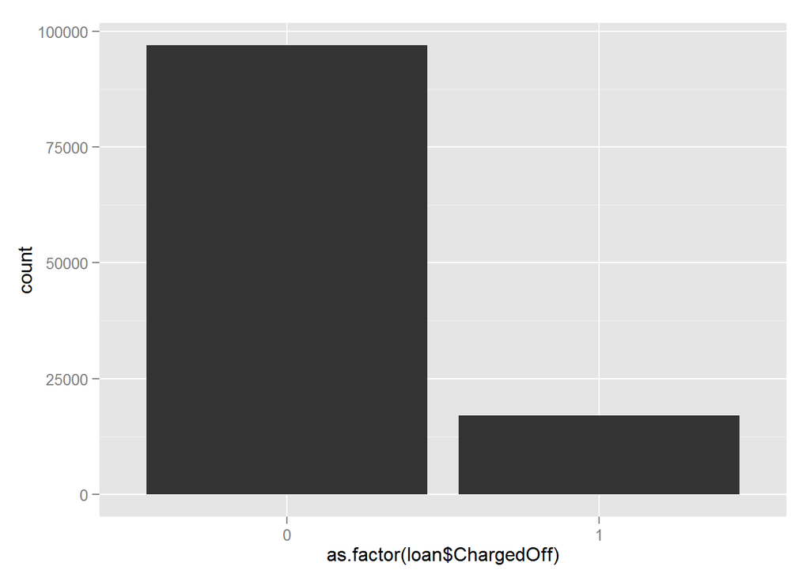

```
##
##         0         1
## 0.8506631 0.1493369
```

My goal in this project is to build a predictive model to assess the default possibility of a loan given the information available at the time the loan is applied and credit report is pulled. In this particular analysis, default (or charged-off) is defined as the state of being charged-off, cancelled or default. First, I split the data into charged-off and non-charged-off groups using variable ChargedOff. There are 17,015 loans that are considered charged-off and 96,922 loans that are considered completed or in good standing. Charged-off loans account for 15% of the loans at Prosper while good-standing loans account for 85%.

After examing the data, it seems like there are certain variables that are not going to contribute to prediction model such as Listing Key, Listing Number, Date, etc. Also, since I’m interested in creating a model to predict the risk of default of a loan at the moment the borrower completed application for a loan and the loan is granted, I’m just going to use variables that present information exists at this stage such as Credit Grade, Borrower APR, etc. Nevertheless, I’m going to create a variable called “Average Credit Score” to calculate the average credit score from variables Credit Score Upper and Credit Score Lower.

The ending data sets for training the model is as follow

```
## 'data.frame':    104655 obs. of  28 variables:
##  $ Term                              : int  36 36 36 36 60 36 36 36 36 60 ...
##  $ BorrowerAPR                       : num  0.165 0.12 0.125 0.246 0.154 ...
##  $ ProsperRating..Alpha.             : Factor w/ 7 levels "A","AA","B","C",..: 4 1 1 5 3 6 4 2 2 4 ...
##  $ ProsperScore                      : num  6 7 9 4 10 2 4 9 11 7 ...
##  $ ListingCategory..numeric.         : int  0 2 16 2 1 1 2 7 7 1 ...
##  $ EmploymentStatus                  : Factor w/ 7 levels "Employed","Full-time",..: 7 1 1 1 1 1 1 1 1 1 ...
##  $ IsBorrowerHomeowner               : Factor w/ 2 levels "False","True": 2 1 2 2 2 1 1 2 2 1 ...
##  $ CurrentCreditLines                : int  5 14 5 19 21 10 6 17 17 2 ...
##  $ OpenCreditLines                   : int  4 14 5 19 17 7 6 16 16 2 ...
##  $ TotalCreditLinespast7years        : int  12 29 29 49 49 20 10 32 32 56 ...
##  $ OpenRevolvingAccounts             : int  1 13 7 6 13 6 5 12 12 4 ...
##  $ OpenRevolvingMonthlyPayment       : num  24 389 115 220 1410 214 101 219 219 25 ...
##  $ InquiriesLast6Months              : int  3 3 0 1 0 0 3 1 1 1 ...
##  $ TotalInquiries                    : num  3 5 1 9 2 0 16 6 6 2 ...
##  $ CurrentDelinquencies              : int  2 0 4 0 0 0 0 0 0 1 ...
##  $ PublicRecordsLast10Years          : int  0 1 0 0 0 0 1 0 0 1 ...
##  $ RevolvingCreditBalance            : num  0 3989 1444 6193 62999 ...
##  $ BankcardUtilization               : num  0 0.21 0.04 0.81 0.39 0.72 0.13 0.11 0.11 0.51 ...
##  $ AvailableBankcardCredit           : num  1500 10266 30754 695 86509 ...
##  $ TotalTrades                       : num  11 29 26 39 47 16 10 29 29 47 ...
##  $ TradesNeverDelinquent..percentage.: num  0.81 1 0.76 0.95 1 0.68 0.8 1 1 0.72 ...
##  $ TradesOpenedLast6Months           : num  0 2 0 2 0 0 0 1 1 0 ...
##  $ DebtToIncomeRatio                 : num  0.17 0.18 0.15 0.26 0.36 0.27 0.24 0.25 0.25 0.12 ...
##  $ IncomeRange                       : Factor w/ 7 levels "$1-24,999","$100,000+",..: 3 4 3 2 2 3 3 3 3 5 ...
##  $ IncomeVerifiable                  : Factor w/ 2 levels "False","True": 2 2 2 2 2 2 2 2 2 2 ...
##  $ ChargedOff                        : num  0 0 0 0 0 0 0 0 0 0 ...
##  $ AverageCreditScore                : num  650 690 810 690 750 ...
##  $ ProsperPrincipalOutstanding       : num  0 0 0 9948 0 ...
```

Then I used randomForest to determine the variables that are significant to my model. The way random forest works is that it tries to grow n trees by randomly combine m number of variables as candidate for each node splt in each tree. Using cross validation techniques, it is able to train on different sets of train and test data, where the samples for each set are drawn randomly. Variable importance is determined at each tree using the decrease is prediction accuracy rate and the decrease in GINI impurity (a measure for node impurity) when that variable is removed from the model. The average of these measures accross all trees will determine the final variable importance.

```
##                             MeanDecreaseAccuracy MeanDecreaseGini
## BorrowerAPR                           0.04318891        1721.5458
## EmploymentStatus                      0.02230302        1153.5454
## ProsperRating..Alpha.                 0.01778801         382.5587
## RevolvingCreditBalance                0.01347550        1049.4219
## OpenRevolvingMonthlyPayment           0.01284870        1048.1212
## AverageCreditScore                    0.01174213        1147.4132
## ListingCategory..numeric.             0.01053687         713.1700
## ProsperScore                          0.01020179         508.9172
## BankcardUtilization                   0.01019134         932.0638
## AvailableBankcardCredit               0.01003492        1127.8667
```

### Borrower APR

```
##    Min. 1st Qu.  Median    Mean 3rd Qu.    Max.
## 0.00653 0.15710 0.21020 0.21990 0.28540 0.42400
```

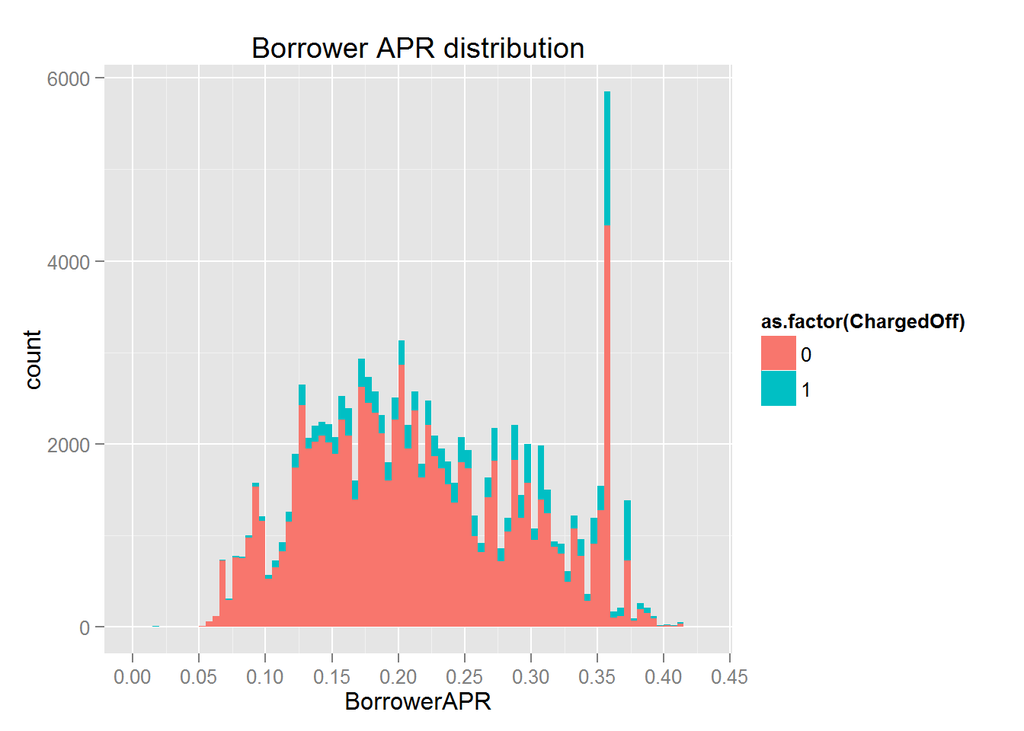

### Open revolving monthly payment

```
##    Min. 1st Qu.  Median    Mean 3rd Qu.    Max.
##     0.0   131.0   288.0   413.5   542.0 14980.0
```

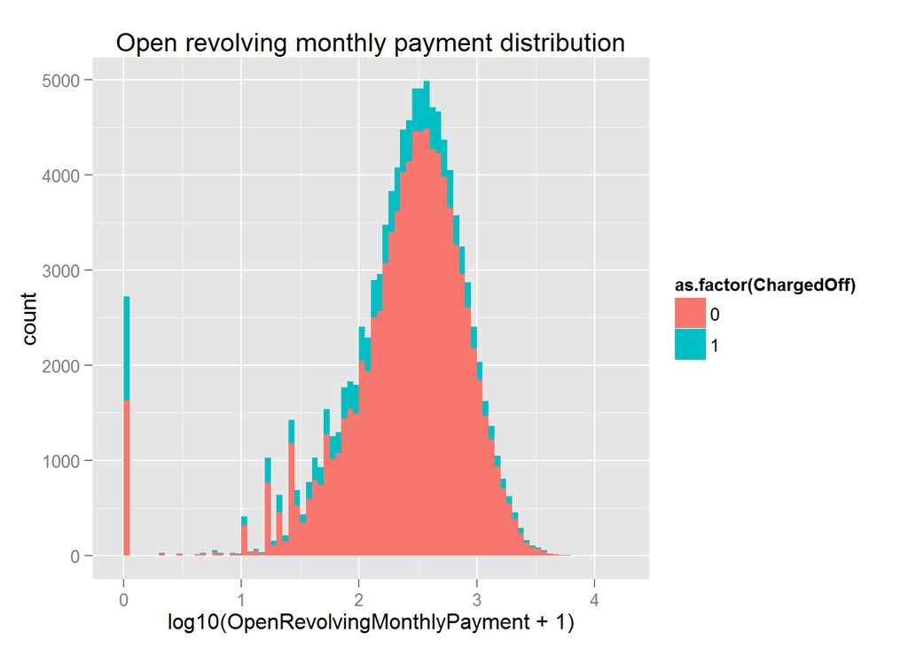

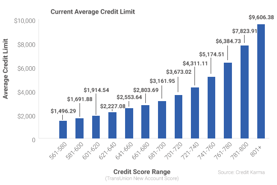

Ref: https://www.creditkarma.com/article/relationship_score_and_credit_limits

### Revolving credit balance

```
##    Min. 1st Qu.  Median    Mean 3rd Qu.    Max.
##       0    3164    8598   17580   19550 1436000
```

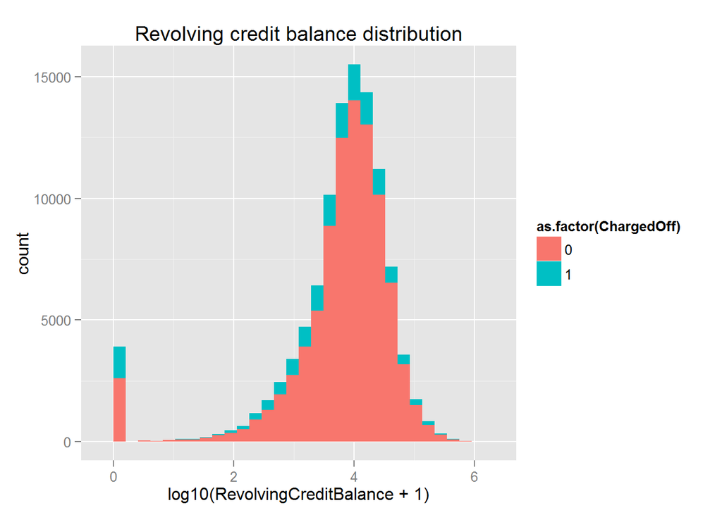

A log 10 transformation is used to explore the distribution of borrowers’ revolving credit balance. As the graph shows, most borrowers have about $3,162 to $19,540 worth of revolving credit balance. I wonder does the amount of revolving accounts would increase the risk of being charged off. The max number is pretty high ($1,436,000) and the data over all is very spread out, with 25, 50, and 75th percentile pretty far from each other. Also, there is a lot of people with no credit balance. Interestingly, borrowers with low credit balance or very high credit balance have lower default risk than borrowers with no credit balance or have medium amount of credit balance. I’m assuming that people with higher credit score are able to borrow more, and these are the people that do not usually default on their loans. Also, smaller credit balance is easy to manage, and not a lot of people default on small credit balance either.

One of the things that make me curious is why there are more people with zero revolving credit balance that default. One of my theory is that these people may be denied credit due to their low credit score. It turns out that most borrowers who default and have no revolving credit balance have average credit score of about 650.

```
##    Min. 1st Qu.  Median    Mean 3rd Qu.    Max.
##   529.5   569.5   649.5   642.2   689.5   829.5
```

### Available bank card credit

```
##    Min. 1st Qu.  Median    Mean 3rd Qu.    Max.
##       0     886    4102   11190   13180  572400
```

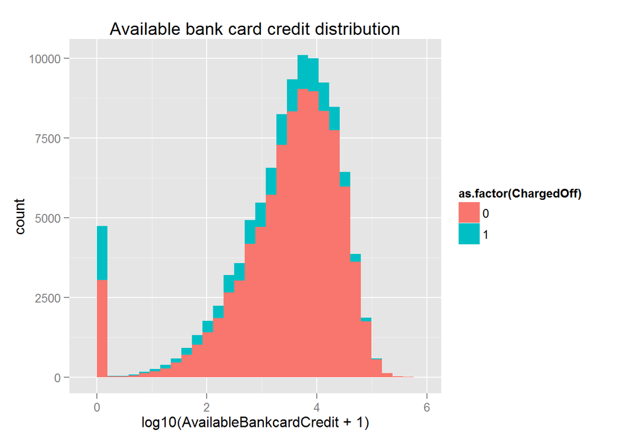

### Average credit score

```
##    Min. 1st Qu.  Median    Mean 3rd Qu.    Max.
##   529.5   669.5   689.5   700.7   729.5   889.5
```

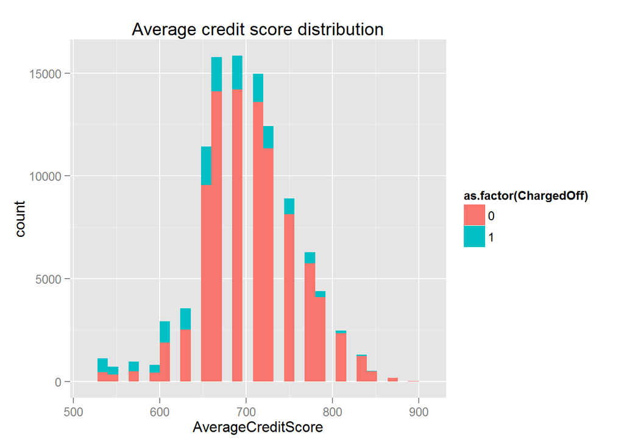

The graph shows that 75% of borrowers have credit score below 730. Credit scores are pretty normally distributed with mean score of around 701. The max credit score is 889.5. It turns out that my thought is correst. Lower credit scores does result in higher charged-off risk.

### Total inquiries

```
##    Min. 1st Qu.  Median    Mean 3rd Qu.    Max.
##    0.00    2.00    4.00    5.25    7.00  158.00
```

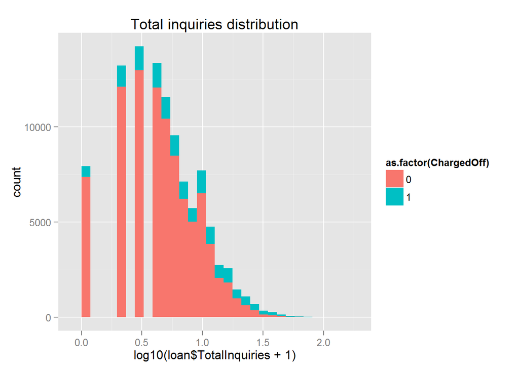

### Employment status

```
##      Employed     Full-time  Not employed         Other     Part-time
##         67298         25885            71          3805          1019
##       Retired Self-employed
##           779          5798
```

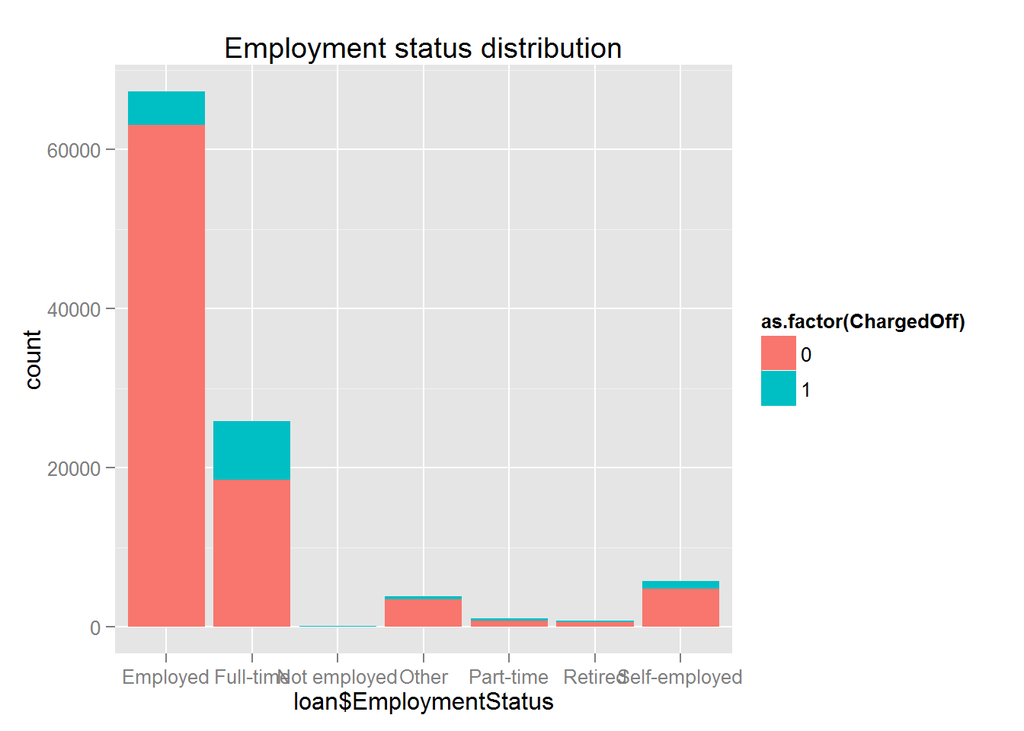

Employment status data is changed to combine “Not available” to “Other” and remove “”. This assumes that “Not available” provides the similar absence of information as “Other”. The graph shows that most people are employed. However, the category seems to overlapse each other and not consistent, because the amount of people work full-time, part-time, and self-employed do not add up to number of people employed. Also, it seems like the probability of default is higher in “full-time” category. Yet, we do not know what this “full-time” really means, thus not a lot of information can be gained from this distribution.

### Bank card utilization

```
##    Min. 1st Qu.  Median    Mean 3rd Qu.    Max.
##  0.0000  0.3100  0.6000  0.5626  0.8400  5.9500
```

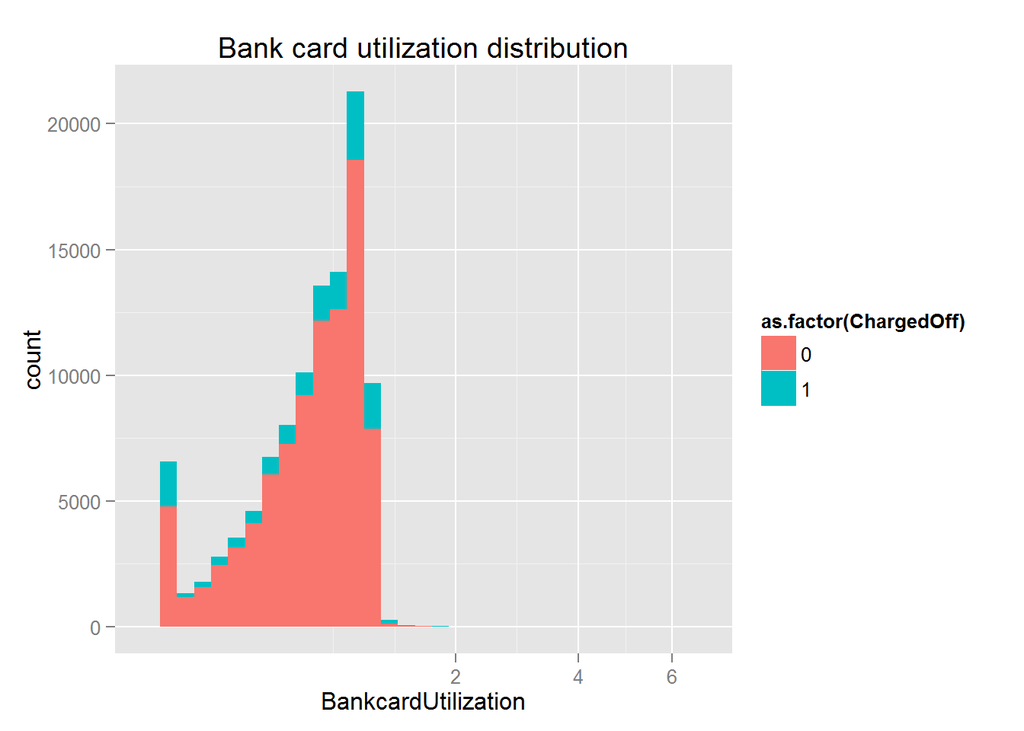

```
## [1] 1715
```

The graph shows that 75% of borrowers uses less than 84% of bank card credit. The average percentage of bank card used is 56%. On the extreme side, some borrowers used more than their credit card allowed (1715 borrowers). We can also see that the risk is high for people who don’t use their credit cards (or they never used one), or used the cards heavily.

# Univariate Analysis

### What is the structure of your dataset?

There are 113937 loan listing in the data set with 81 variables. I transformed the data into a new data with variables that are relevant to predicting whether a Prosper loan will be charged-off. There are a total of 5 factor variables in the new dataset. Among these variables, interesting ones that might provide some insight into predicting charged-off loans are:

**income verifiable**: yes, no

**is borrower homeowner**: yes, no

**employment status**: Employed, Full-time, Not employed, Other, Part-time, Retired, Self-employed

**income range**: $0, $1-24,999, $100,000+,$25,000-49,999, $50,000-74,999, $75,000-99,999, Not employed

**Prosper rating alpha**: AA, A, B, C, D, E, HR

**listing category numeric**: 1, 2, 3, 4, 5, 6, 7, 8, 9, 10, 11, 12, 13, 14, 15, 16, 17, 18, 19, 20 (description of each number is described in Prosper code book)

Other observations:

Average revolving monthly payment of each borrower is 398.3.

75% of borrowers have debt-to-income ratio of less tthan 0.32.

The average number of current deliquencies for each borrower is 0.5921.

### What is/are the main feature(s) of interest in your dataset?

The main features in the data set are APR, credit scores, and loan status (especially charged-off, cancelled, and default status). These data are provided by credit agencies and Prosper. I wonder is there enough information from these metrics to give a fairly accurate estimate of the default risk.

### What other features in the dataset do you think will help support your investigation into your feature(s) of interest?

The other features in the data set are open revolving monthhly payment, open revolving accounts, employment status, income range, available bank card credit, and revolving credit balance. Since most of these financial information is already included in borrowers’ APR, I would love to see how their employment status would affect their default risk.

### Did you create any new variables from existing variables in the dataset?

Yes. In order to investigate the effect of credit score on default risk, I created the variable average credit score, which is the average of lower and upper bound of credit score for each loan. This metric helps simplify the range to a specific number and ease the comparision and other mathematical functions.

### Of the features you investigated, were there any unusual distributions? Did you perform any operations on the data to tidy, adjust, or change the form of the data? If so, why did you do this?

# Bivariate Plots Section

Multi-colinearity might be a problem in several prediction models, but it is not significant for random forest algorithm. The reason for this is that each tree in random forest will split on the variable that results in the smallest impurity, until a certain level of impurity is reached at each leaf node. Yet, this might pose some problem when interpreting the final result. If wo important variables are in the same tree, using one of them to split might cause reduction in predictive power of the other (because they tend to explain the same thing). For example, when you consider lower APR as charged-off loans and higher APR as non-charged-off loans, then lower APR loans will also have lower interest rate and vice versa. Thus, if we were to split the low APR group with interest rate variable, we can’t really do that because all of them have low interest rate! Since random forest uses random bootstrap of variables, it might create several trees which contain the same correlated variables. Thus, when determining the importance of each variable, multi-colinearity may tell us an important variable as non-important. To overcome this, I will look for highly correlated variables using a plot matrix.

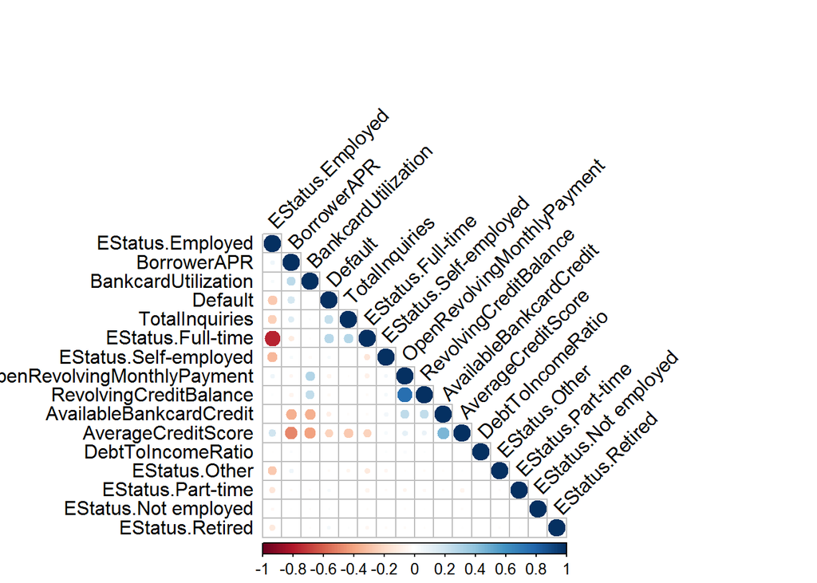

The graph shows that there are quite a few pairs of variables that highly correlated with each other. Some of the unexpected correlations are the correlation between bank card utilization and credit score, bank card utilization and APR. Also, it seems that APR has correlations with most variables. This is expected since APR is derived by Prosper based on other important financial information. Also, it shows that default (or charged-off) is correlated with APR, being employed, and total inquiries. This suggest that these variables might contribute mostly to our classifier. I will check pairs of important variables, important and weak variables, and important and dependent variables.

### Average credit score vs Bank card utilization

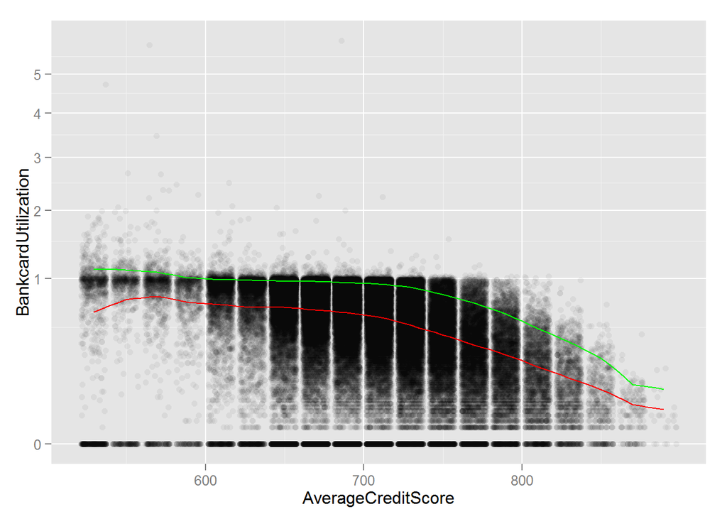

The red line shows that the mean of bank card utilization drops as average credit score increases. This may suggest that people with better credit are more careful with their credit utilization? Also, the scatter plot shows that most loans have score within 600-700 and borrowers in this range use almost all of their available revolving credit (green line shows the 90th percentile of data).

```
##
##  Pearson's product-moment correlation
##
## data:  AverageCreditScore and BankcardUtilization
## t = -143.4, df = 104650, p-value < 2.2e-16
## alternative hypothesis: true correlation is not equal to 0
## 95 percent confidence interval:
##  -0.4102920 -0.4001647
## sample estimates:
##        cor
## -0.4052408
```

As we can see with correlation test, the correlation is quite hight, around -0.405

### Average credit score vs Revolving credit balance

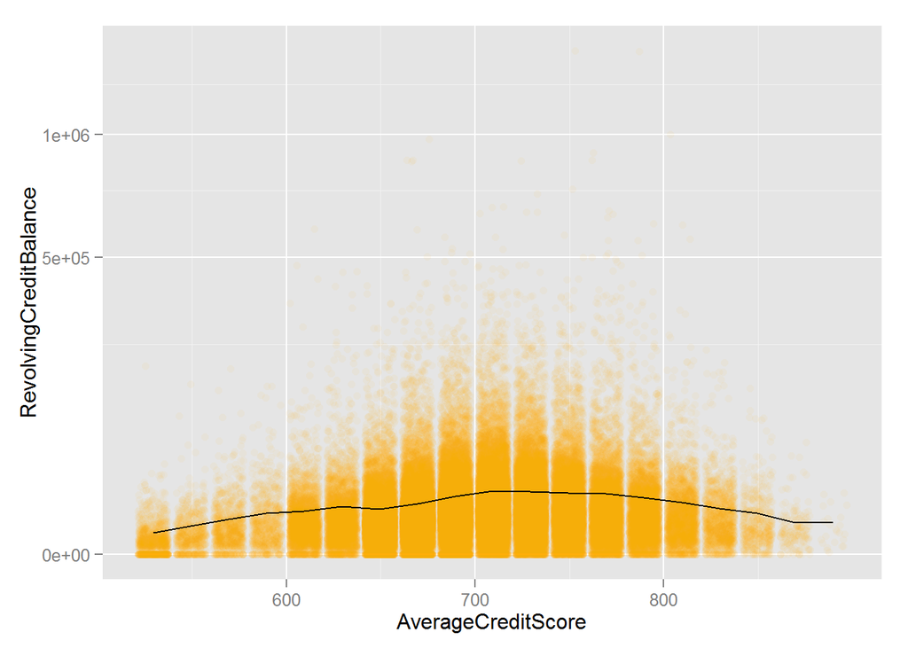

```
##
##  Pearson's product-moment correlation
##
## data:  AverageCreditScore and RevolvingCreditBalance
## t = 29.209, df = 104650, p-value < 2.2e-16
## alternative hypothesis: true correlation is not equal to 0
## 95 percent confidence interval:
##  0.08391224 0.09593137
## sample estimates:
##        cor
## 0.08992508
```

The correlation is estimated to be 0.0898

### Average credit score vs Available Bankcard credit

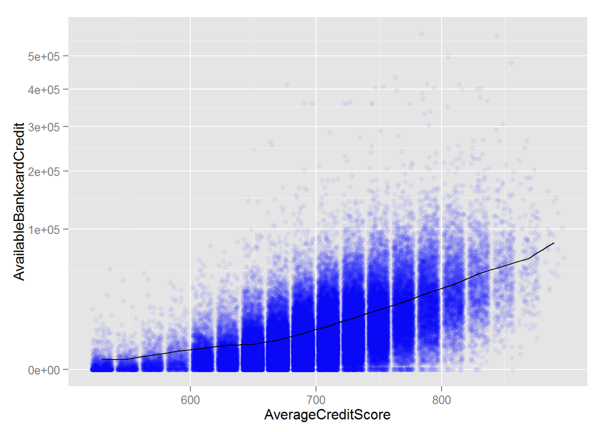

The graph displays a strong relationship between Available Bankcard Credit and Average Credit Score. It proves that credit score is heavily used in financial industry to determine credit allowance, as we can see good credit score means bigger credit balance.

[output not shown]